# G Luku 1 Yksinkertainen korrespondenssianalyysi

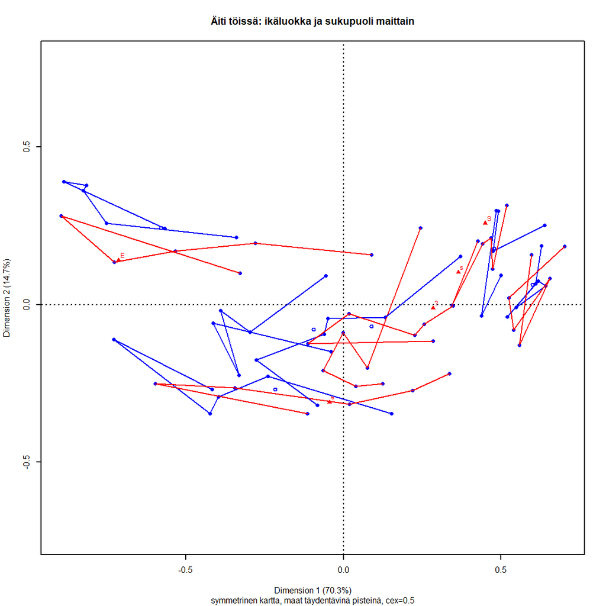

Ikä-sukupuoli-maa

```r
# Onko yhtään vähemmän tukkoinen? Eipä juuri (17.9.20)
par(cex = 0.5)
plot(spCAmaaga1, labels = c(0,2) , main = "Äiti töissä: ikäluokka ja sukupuoli maittain",
                sub = "symmetrinen kartta, maat täydentävinä pisteinä, cex=0.5"
                    )
     lines(maagaLines1[49:54,1],maagaLines1[49:54,2], col="blue") #FIf
     lines(maagaLines1[55:60,1],maagaLines1[55:60,2], col="red")  #FIm
     lines(maagaLines1[25:30,1],maagaLines1[25:30,2], col="blue") #DEf
     lines(maagaLines1[31:36,1],maagaLines1[31:36,2], col="red")  #DEm
     lines(maagaLines1[37:42,1],maagaLines1[37:42,2], col="blue") #DKf
     lines(maagaLines1[43:48,1],maagaLines1[43:48,2], col="red")  #DKm
     lines(maagaLines1[1:6,1],maagaLines1[1:6,2], col="blue") #BEf
     lines(maagaLines1[7:12,1],maagaLines1[7:12,2], col="red")  #BEm
     lines(maagaLines1[13:18,1],maagaLines1[13:18,2], col="blue") #BGf
     lines(maagaLines1[19:24,1],maagaLines1[19:24,2], col="red")  #BGm
     lines(maagaLines1[61:66,1],maagaLines1[61:66,2], col="blue") #HUf
     lines(maagaLines1[67:72,1],maagaLines1[67:72,2], col="red")  #HUm
```

Rivipisteiden tunnisteiden (label) poistaminen tuo pisteparvien ominaisuuden hieman selvemmin esiin. Suomi alimpana ja Tanska ylimpänä vasemmalla ovat melko samanlaisia. Vaihtelu on lähes täysin ensimäisen dimension suuntaan, Molemmilla mailla miesten pisteet ovat oikealla ja alempana. Keskellä Saksan ja Belgian pistejoukoissa vaihtelu toisen dimension suunnassa on jo suurempaa ja miesten pisteet ovat selvästi oikealla verrattuna naisten pisteisiin. Bulgarian ja Unkarin pisteet sijaitsevat kauimpana oikealla, ja vaihtelu on suurimmalta osin toisen dimensio suuntaan, ja pisteet ovat tiukemmin lähellä toisiaan. Kaikissa maissa vanhemmat ikäluokat ovat nuoria konservatiivimsempia, ja kaikissa nuorin ikäluokka on melko konservatiivinen. Keskimmäiset ikäluokat ovat liberaaleimpia. Unkari ja Bulgaria poikkeavat muista selvästi.

## 4.4 Kartan rajaaminen

0. Analyysin voi tehdä vain osalle dataa - vähän kehno ratkaisu, ei yhteyttä koko aineiston antamaan yleiskuvaan muuttujien yhteyksistä.
1. Kartasta voi suurentaa osan käsityönä (“leikkaa ja liimaa”). Toimii, yksinkertainen ja ehkä siksi paras? Mutta ei voi koodata! Sopii eksploratiiviseen vaiheeseen, pdf-kuviin voi liittää kommenteja ja tekstiä jne.
2. BaseR plot-funktiolla voi rakentaa kartan pala kerrallaan ja rajata kuva-alan johonkin kartan osaan. Työlästä, hankalaa? Yllättäen ei, kun asettaa koodilohkon option Rmarkdownissa oikein! (9.9.20). Jos käytetään yhtä ca-funktion tulosobjektia, pelkkiä plot-komentoja.
3. Osajoukon korrespondenssianalyysi (subset ca)

*zxy** Tässä vain lyhyt kuvaus subset ca:n perusideasta

### 4.4.1 Kuva-alueen rajaaminen

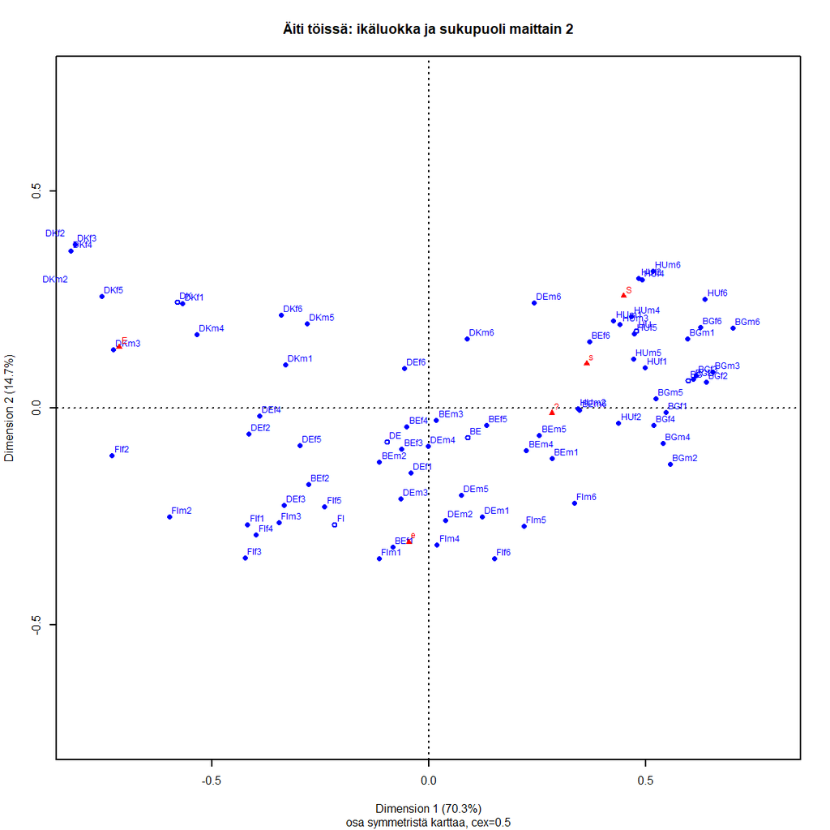

Ikä-sukupuoli-maa

```r
# Zoomaus - esimerkki (24.2.20) xlim=c(-0.5,0.5), ylim=c(-0.6,0.4)
# EI TOIMI - PISTEET piirrettävä, ei voi käyttää ca.plot - funktiota? (4.5.20).
# MG2017 laskarit - day3: mca:n tuloslistaa käytetty luottamusellipseissä ja toimii?
# Piirtää pisteitä koko "plot-alueelle"?

#X11()

# Rivi- ja sarakekoordinaatit (principal coordinates) talteen
maagaCA1.rpc <- spCAmaaga1$rowcoord %*% diag(simpleCA1$sv)
maagaCA1.cpc <- spCAmaaga1$colcoord %*% diag(simpleCA1$sv)
par(cex = 0.5)

plot(spCAmaaga1, xlim = c(-0.75,0.75), ylim = c(-0.75,0.75),
                main = "Äiti töissä: ikäluokka ja sukupuoli maittain 2",
                sub = "osa symmetristä karttaa, cex=0.5"
                    )
```

```r
# TÄTÄ KEHITELLÄÄ CAcalc_1.R - skriptissä (15.6.20)
# ei toimi ihan toivotulla tavalla - tarkoitettu komentoriviltä
# grafiikkaikkunaan tulostukseen ?
# Vai pitääkö ensin piirtää kuvan "kehys" ilman pisteitä xlim- ja ylim- parametreilla
# ja sitten vasta pisteet?
# Kuvasuhde oikein, kun xlim = ylim, miten turhat pisteet pois? (29.5.20).Menevät
# näköjään kuva-alueen ja ulomman marginaalin väliin.

# Voisiko valita objektista vain osan pisteistä? Tai plot ilman tulostusta, tulos
# objektiin ja sieltä pisteet kuvaan? (29.5.20)
# str(spCAmaaga1)
```

Ei toimi ihan odotetulla tavalla, mutta kuvasuhde näyttäisi olevan molemmissa oikea. Hieman hankala menetelmä.

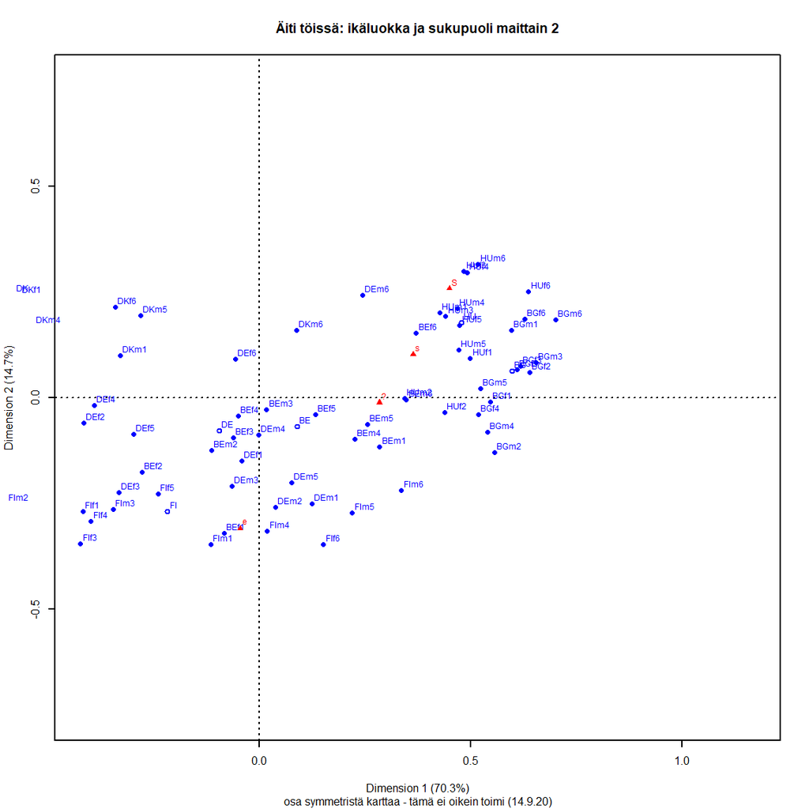

Ikä-sukupuoli-maa

```r
# Zoomaus - esimerkki (24.2.20) xlim=c(-0.5,0.5), ylim=c(-0.6,0.4)
# EI TOIMI - PISTEET piirrettävä, ei voi käyttää ca.plot - funktiota? (4.5.20).
# MG2017 laskarit - day3: mca:n tuloslistaa käytetty luottamusellipseissä ja toimii?
# Piirtää pisteitä koko "plot-alueelle"?


# Rivi- ja sarakekoordinaatit (principal coordinates) talteen
maagaCA1.rpc <- spCAmaaga1$rowcoord %*% diag(simpleCA1$sv)
maagaCA1.cpc <- spCAmaaga1$colcoord %*% diag(simpleCA1$sv)
par(cex = 0.5)

plot(spCAmaaga1, xlim = c(0,0.75), ylim = c(-0.75,0.75),
                main = "Äiti töissä: ikäluokka ja sukupuoli maittain 2",
                sub = "osa symmetristä karttaa - tämä ei oikein toimi (14.9.20)"
                    )
```

```r
# TÄTÄ KEHITELLÄÄ CAcalc_1.R - skriptissä (15.6.20)
# ei toimi ihan toivotulla tavalla - tarkoitettu komentoriviltä
# grafiikkaikkunaan tulostukseen ?
# Vai pitääkö ensin piirtää kuvan "kehys" ilman pisteitä xlim- ja ylim- parametreilla
# ja sitten vasta pisteet?
# Kuvasuhde oikein, kun xlim = ylim, miten turhat pisteet pois? (29.5.20).Menevät
# näköjään kuva-alueen ja ulomman marginaalin väliin.

# Voisiko valita objektista vain osan pisteistä? Tai plot ilman tulostusta, tulos
# objektiin ja sieltä pisteet kuvaan? (29.5.20)
# str(spCAmaaga1)
```

Rivipisteiden inertia on suurempi kuin sarakkeiden. Asymmetrinen kartta näyttää sarakkeet selvemmin.

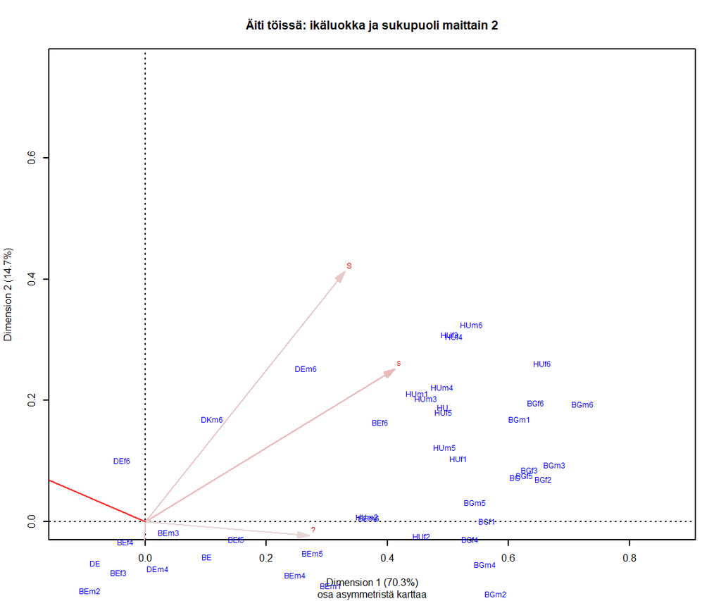

Ikä-sukupuoli-maa

```r
# Zoomaus - esimerkki (24.2.20) xlim=c(-0.5,0.5), ylim=c(-0.6,0.4)
# EI TOIMI - PISTEET piirrettävä, ei voi käyttää ca.plot - funktiota? (4.5.20).
# MG2017 laskarit - day3: mca:n tuloslistaa käytetty luottamusellipseissä ja toimii?
# Piirtää pisteitä koko "plot-alueelle"?


# Rivi- ja sarakekoordinaatit (principal coordinates) talteen
# maagaCA1.rpc <- spCAmaaga1$rowcoord %*% diag(simpleCA1$sv)
# maagaCA1.cpc <- spCAmaaga1$colcoord %*% diag(simpleCA1$sv)

par(cex = 0.5)
plot(spCAmaaga1, map = "rowgreen",
        contrib = c("absolute", "absolute"),
        mass = c(TRUE,TRUE),
        arrows = c(FALSE,TRUE),
        xlim = c(0,0.75), ylim = c(0,0.75),
        main = "Äiti töissä: ikäluokka ja sukupuoli maittain 2",
        sub = "osa asymmetristä karttaa"
        )
```

```r
# TÄTÄ KEHITELLÄÄ CAcalc_1.R - skriptissä (15.6.20)
# ei toimi ihan toivotulla tavalla - tarkoitettu komentoriviltä
# grafiikkaikkunaan tulostukseen ?
# Vai pitääkö ensin piirtää kuvan "kehys" ilman pisteitä xlim- ja ylim- parametreilla
# ja sitten vasta pisteet?
# Kuvasuhde oikein, kun xlim = ylim, miten turhat pisteet pois? (29.5.20).Menevät
# näköjään kuva-alueen ja ulomman marginaalin väliin.

# Voisiko valita objektista vain osan pisteistä? Tai plot ilman tulostusta, tulos
# objektiin ja sieltä pisteet kuvaan? (29.5.20)
# str(spCAmaaga1)
```

Edellinen kartta on vähän epäilyttävä, asettuvatkohan skaalatut sarakevektorin oikein? (9.9.20) ***

## 4.5 Subset CA

Teoria esitetään myöhemnmin, käytännön hyödyllisyys osoitetaan tässä. CA-kartoissa on usein aivan liian paljon pisteitä, vain karkeat yleispiirteet näkyvät. Ovatko kiinnostavat asia piilossa? “Poikkeavat havainnot ovat ainoita todella kiinnostavia havaintoja”.

**Data** Ensimmäinen osajoukko-ca käyttää datan perustiedostoa (ISSP2012esim2.dat). Maa-rivit ovat mukana kokonaislukumatriisissa maagaTab1.

Datassa maa-sukupuoli-ikäluokkarivit ovat näillä riveillä: BE 1-12, BG 13-24, DE 25-36, DK 37-48, FI 49-60, HU 61-72 . Maa-profiilit ovat taulukon(matriisin) maagaTab1 riveillä 73-78 samassa järjestyksessä. **edit 9.9.20** Tarkistettava, miten ca-funktio laskee täydentävien rivien koordinaatit, kun riveistä otetaan analyysiin vain osa.

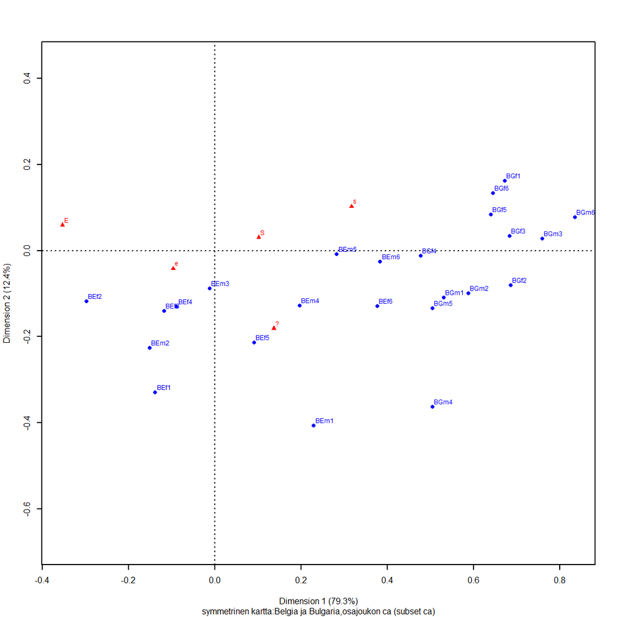

Ikä, sukupuoli ja maa

```r
#31.8.20 Testataan subset ca
#ISSP2012esim2.dat %>% tableX(maaga, Q1b)
maagaCA2subset1BEBG <- ca(~maaga + Q1b,ISSP2012esim2.dat, subsetrow = 1:24)
par(cex = 0.5)
plot(maagaCA2subset1BEBG,
                sub = "symmetrinen kartta:Belgia ja Bulgaria,osajoukon ca (subset ca)"
        )
```

```r
# main = "Äiti töissä: ikäluokka ja sukupuoli maittain" mikä on plot-funktion
# title-asetusten ja koodilohkon asetusten suhde? Ainakin plot-funkiton
# main = "Äiti töissä: ikäluokka ja sukupuoli maittain" korvaa koodilohkossa
# määritellyn (9.9.20). R-markdownissa kuvan pääotsikko putoaa kokonaan pois,
# mitenköhän tulosteissa?
```

Yhdistetään pisteitä.

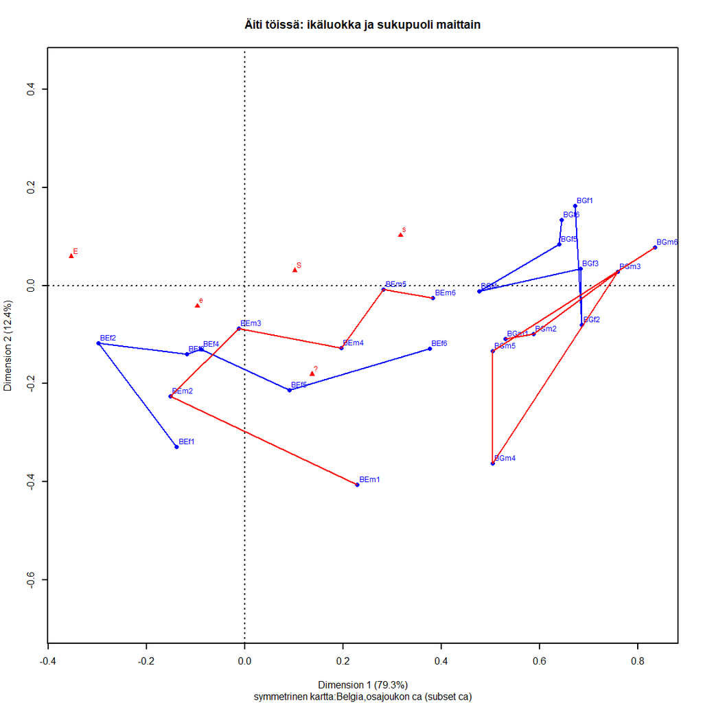

Ikä, sukupuoli ja maa - Belgia

```r
# CA- tulosobjekti maagaCA2subset1

maagaLinesBEBG <- cacoord(maagaCA2subset1BEBG, type = "symmetric")
maagaLinesBEBG <- maagaLinesBEBG$rows[ , 1:2]
par(cex = 0.5)
plot(maagaCA2subset1BEBG,main = "Äiti töissä: ikäluokka ja sukupuoli maittain",
                sub = "symmetrinen kartta:Belgia,osajoukon ca (subset ca)"
        )
lines(maagaLinesBEBG[1:6,1],maagaLinesBEBG[1:6,2], col="blue") #BEf
lines(maagaLinesBEBG[7:12,1],maagaLinesBEBG[7:12,2], col="red")  #BEm
lines(maagaLinesBEBG[13:18,1],maagaLinesBEBG[13:18,2], col="blue") #BBGf
lines(maagaLinesBEBG[19:24,1],maagaLinesBEBG[19:24,2], col="red")  #BEm
```

Kartan tulkintaa, kokonaisinertia voidaan esittää maa kerrallaan. (9.9.20)

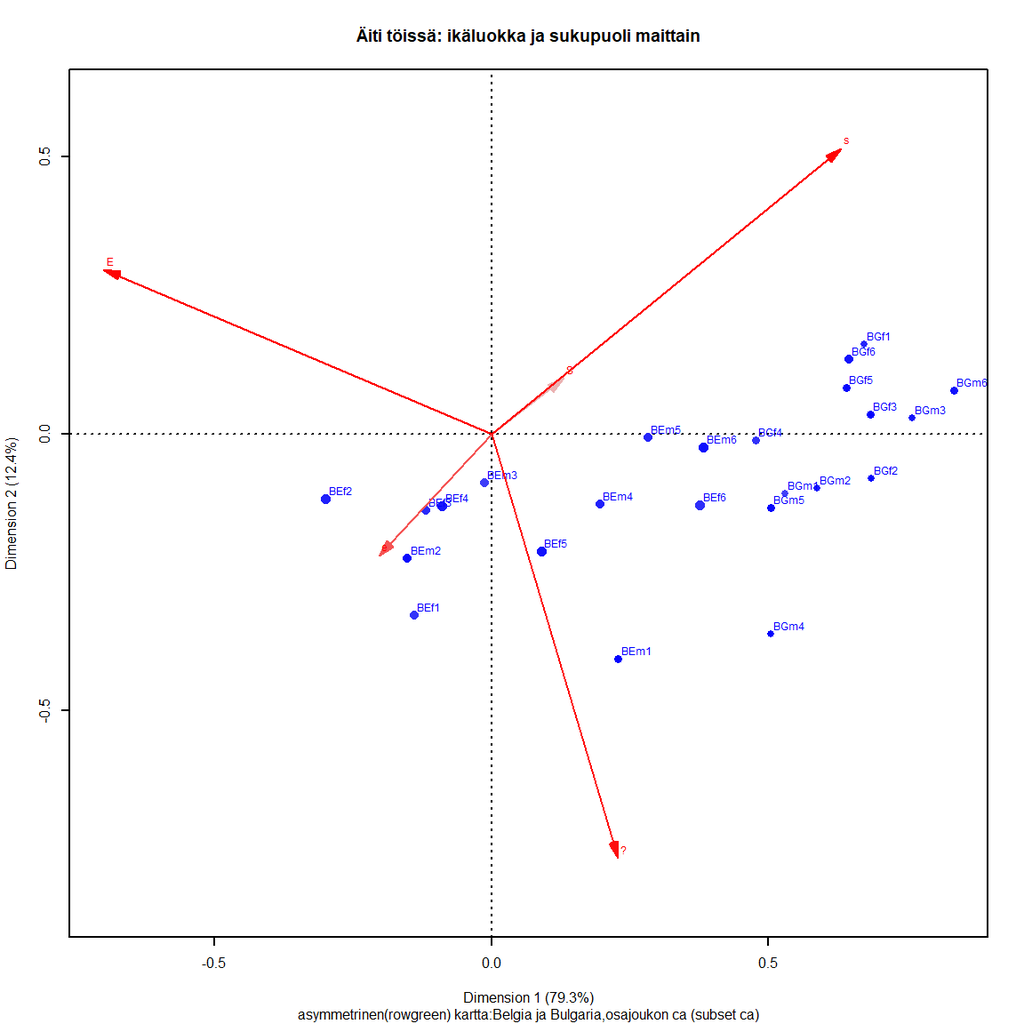

```r
# Datana maagaTab1 - viimeisinä riveinä maarivit

maagaCA2sub1 <- ca(maagaTab1[,1:5], subsetrow = 1:24)
par(cex = 0.5)
plot(maagaCA2sub1, map = "rowgreen",
     contrib = c("relative", "relative"),
     mass = c(TRUE,TRUE),
     arrows = c(FALSE, TRUE),
     main = "Äiti töissä: ikäluokka ja sukupuoli maittain",
     sub = "asymmetrinen(rowgreen) kartta:Belgia ja Bulgaria,osajoukon ca (subset ca)"
        )
```

Lisätään kuvaan täydentävänä (passiivisena) pisteenä Belgian maapiste, tarkistettava tuleeko se “oikeaan” kohtaan. Maapisteiden osajoukon keskiarvopiste ei ole origo, mutta sarakepisteiden on.

```r
# Datana maagaTab1 - viimeisinä riveinä maarivit
maagaTab1
```

|  | S | s | ? | e | E |
| --- | --- | --- | --- | --- | --- |
| BEf1 | 5 | 15 | 28 | 43 | 25 |
| BEf2 | 10 | 26 | 34 | 66 | 62 |
| BEf3 | 19 | 27 | 33 | 53 | 42 |
| BEf4 | 21 | 34 | 40 | 55 | 49 |
| BEf5 | 21 | 38 | 46 | 48 | 33 |
| BEf6 | 25 | 58 | 50 | 30 | 22 |
| BEm1 | 9 | 19 | 30 | 24 | 10 |
| BEm2 | 10 | 19 | 31 | 40 | 35 |
| BEm3 | 18 | 33 | 31 | 44 | 36 |
| BEm4 | 19 | 46 | 37 | 51 | 23 |
| BEm5 | 15 | 61 | 34 | 49 | 23 |
| BEm6 | 19 | 75 | 44 | 49 | 21 |
| BGf1 | 2 | 21 | 7 | 9 | 1 |
| BGf2 | 7 | 28 | 17 | 12 | 0 |
| BGf3 | 10 | 44 | 21 | 18 | 1 |
| BGf4 | 14 | 30 | 15 | 24 | 2 |
| BGf5 | 16 | 51 | 21 | 25 | 1 |
| BGf6 | 27 | 66 | 26 | 27 | 3 |
| BGm1 | 8 | 12 | 9 | 7 | 1 |
| BGm2 | 4 | 21 | 12 | 14 | 0 |
| BGm3 | 5 | 33 | 16 | 11 | 0 |
| BGm4 | 7 | 19 | 21 | 15 | 1 |
| BGm5 | 12 | 29 | 21 | 19 | 3 |
| BGm6 | 6 | 41 | 19 | 9 | 0 |
| DEf1 | 5 | 28 | 13 | 33 | 23 |
| DEf2 | 9 | 14 | 14 | 37 | 46 |
| DEf3 | 10 | 22 | 12 | 59 | 49 |
| DEf4 | 11 | 31 | 20 | 53 | 71 |
| DEf5 | 8 | 27 | 12 | 43 | 45 |
| DEf6 | 31 | 40 | 15 | 50 | 49 |
| DEm1 | 6 | 26 | 20 | 36 | 15 |
| DEm2 | 7 | 26 | 13 | 39 | 18 |
| DEm3 | 11 | 24 | 15 | 45 | 27 |
| DEm4 | 22 | 39 | 17 | 57 | 37 |
| DEm5 | 11 | 43 | 19 | 54 | 26 |
| DEm6 | 34 | 55 | 28 | 32 | 32 |
| DKf1 | 7 | 11 | 9 | 15 | 41 |
| DKf2 | 4 | 15 | 7 | 13 | 71 |
| DKf3 | 3 | 20 | 15 | 14 | 84 |
| DKf4 | 5 | 24 | 8 | 19 | 90 |
| DKf5 | 6 | 16 | 11 | 22 | 73 |
| DKf6 | 5 | 26 | 11 | 17 | 40 |
| DKm1 | 10 | 21 | 18 | 28 | 47 |
| DKm2 | 2 | 11 | 9 | 16 | 65 |
| DKm3 | 2 | 13 | 12 | 23 | 59 |
| DKm4 | 4 | 24 | 14 | 24 | 59 |
| DKm5 | 11 | 14 | 23 | 18 | 40 |
| DKm6 | 11 | 43 | 15 | 23 | 27 |
| FIf1 | 3 | 9 | 13 | 36 | 33 |
| FIf2 | 5 | 6 | 3 | 34 | 47 |
| FIf3 | 2 | 8 | 13 | 39 | 32 |
| FIf4 | 3 | 15 | 13 | 47 | 40 |
| FIf5 | 6 | 26 | 17 | 52 | 41 |
| FIf6 | 3 | 22 | 21 | 34 | 11 |
| FIm1 | 1 | 9 | 13 | 22 | 13 |
| FIm2 | 2 | 5 | 6 | 28 | 30 |
| FIm3 | 2 | 10 | 9 | 27 | 23 |
| FIm4 | 8 | 23 | 13 | 43 | 18 |
| FIm5 | 5 | 31 | 15 | 35 | 10 |
| FIm6 | 7 | 24 | 13 | 26 | 5 |
| HUf1 | 11 | 13 | 16 | 11 | 3 |
| HUf2 | 15 | 19 | 25 | 22 | 5 |
| HUf3 | 22 | 26 | 26 | 12 | 9 |
| HUf4 | 24 | 25 | 20 | 14 | 8 |
| HUf5 | 21 | 28 | 19 | 19 | 7 |
| HUf6 | 33 | 30 | 18 | 21 | 2 |
| HUm1 | 9 | 15 | 12 | 8 | 5 |
| HUm2 | 18 | 13 | 15 | 22 | 7 |
| HUm3 | 15 | 38 | 24 | 16 | 10 |
| HUm4 | 14 | 29 | 17 | 13 | 7 |
| HUm5 | 19 | 31 | 24 | 21 | 7 |
| HUm6 | 18 | 21 | 9 | 11 | 5 |
| BE | 191 | 451 | 438 | 552 | 381 |
| BG | 118 | 395 | 205 | 190 | 13 |
| DE | 165 | 375 | 198 | 538 | 438 |
| DK | 70 | 238 | 152 | 232 | 696 |
| FI | 47 | 188 | 149 | 423 | 303 |
| HU | 219 | 288 | 225 | 190 | 75 |

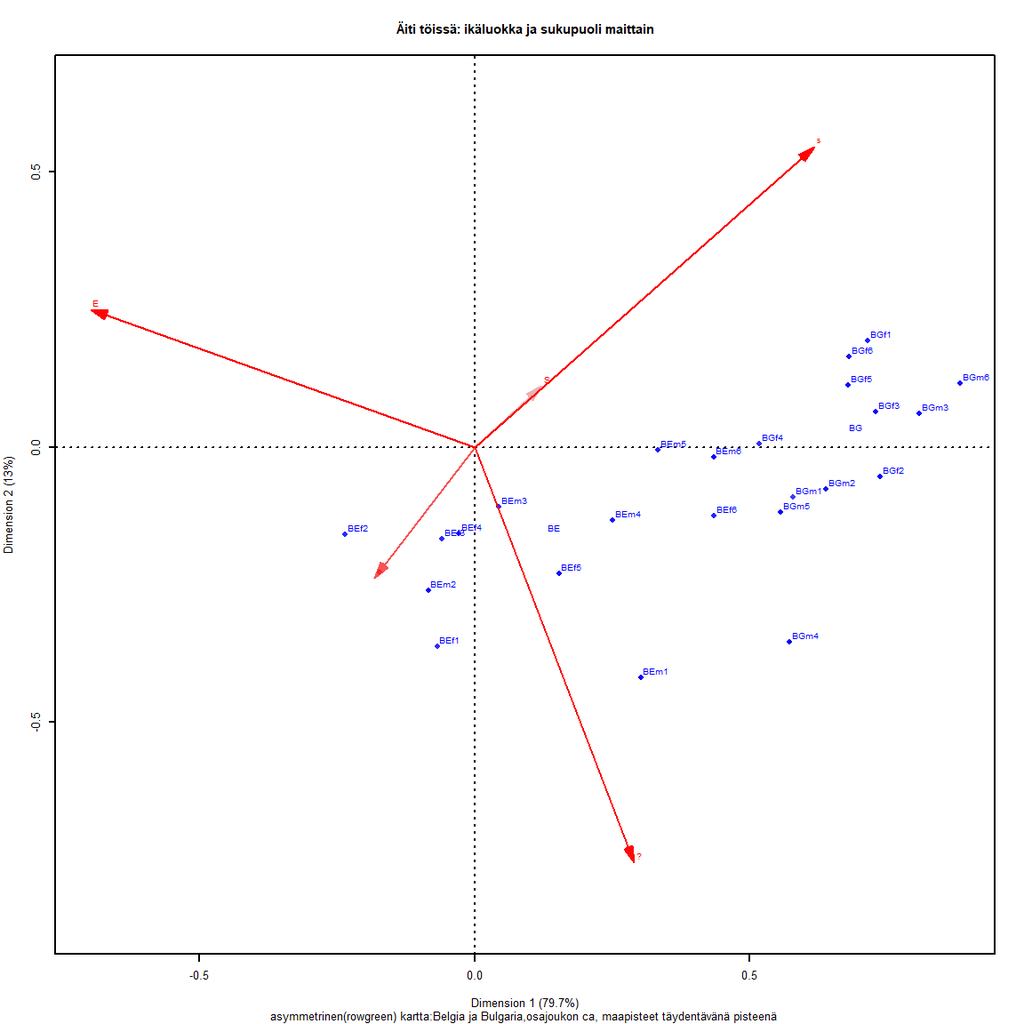

```r
maagaCA2sub2 <- ca(maagaTab1[,1:5], subsetrow = 1:24, suprow = 73:74)
par(cex = 0.4)
plot(maagaCA2sub2, map = "rowgreen",
     contrib = c("relative", "relative"),
     mass = c(FALSE, TRUE),
     arrows = c(FALSE, TRUE),
     main = "Äiti töissä: ikäluokka ja sukupuoli maittain",
     sub = "asymmetrinen(rowgreen) kartta:Belgia ja Bulgaria,osajoukon ca, maapisteet täydentävänä pisteenä "
        )
```

Belgian kolme aluetta täydentäviksi pisteiksi? **Ei tehdä, aika iso duuni.(9.9.20)**

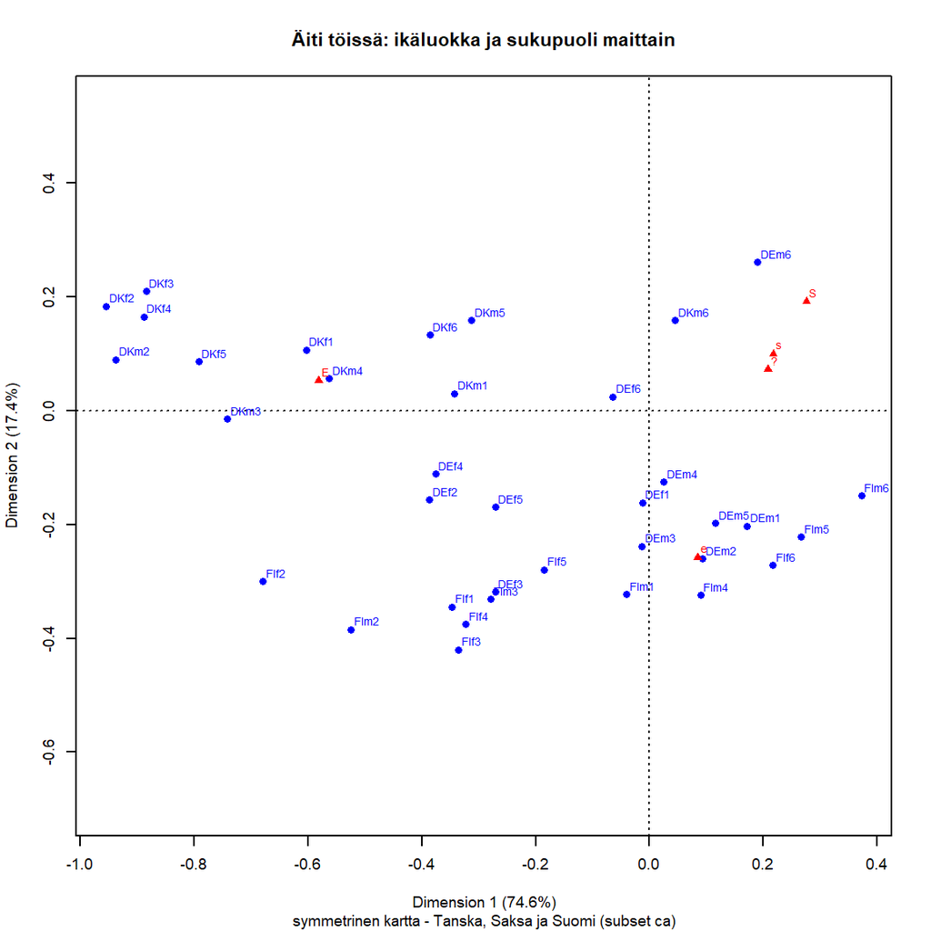

```r
# ISSP2012esim2.dat
# spCAmaaga1    maaga-ca-objekti (täydentävillä maa-pisteillä)
# maagaTab1     taulukko  jossa maaga-rivit ja maat täydentävinä pisteinä
#
# Ongelma 1: miten saa maarivit kätevästi? Tässä tapauksessa näin
# maagaTab1
# Taulukon viimeisillä riveillä maa-profiilit frekvensseinä
# maaga-rivit ovat samassa järjestyksessä, kuusi naisten ja kuusi miesten
# ikäryhmää
# ISSP2012esim2.dat %>% tableX(maaga, Q1b)
#
# BE   191 451 438 552 381
# BG   118 395 205 190  13
# DE   165 375 198 538 438
# DK    70 238 152 232 696
# FI    47 188 149 423 303
# HU   219 288 225 190  75
#
# BE 1-12, BG 13-24, DE 25-36, DK 37-48, FI 49-60, HU 61-72, maarivi
# Hoitaako ca-paketti automaattisesti täydentävien pisteiden "skaalauksen
# subsetCA:ssa? Sarakepisteiden keskiarvo on origossa, mutta rivien osajoukon
# keskiarvo ei ole ja tämä pitäisi korjata.

maagaCA2sub2 <- ca(~maaga + Q1b,ISSP2012esim2.dat,subsetrow = 25:60)
par(cex = 0.6)
plot(maagaCA2sub2, main = "Äiti töissä: ikäluokka ja sukupuoli maittain",
     sub = "symmetrinen kartta - Tanska, Saksa ja Suomi (subset ca)")
```

Sama kuva - yhdistetään pisteitä janoilla.

```r
# ca-tulosobjekti maagaCA2sub2, DK DE FI

maagaLinesDKDEFI <- cacoord(maagaCA2sub2, type = "symmetric")
maagaLinesDKDEFI <- maagaLinesDKDEFI$rows[ , 1:2]
maagaLinesDKDEFI
```

|  | Dim1 | Dim2 |
| --- | --- | --- |
| DEf1 | -0.0122683 | -0.1617268 |
| DEf2 | -0.3865882 | -0.1566004 |
| DEf3 | -0.2706794 | -0.3184381 |
| DEf4 | -0.3756920 | -0.1108647 |
| DEf5 | -0.2706035 | -0.1694576 |
| DEf6 | -0.0642786 | 0.0244026 |
| DEm1 | 0.1718294 | -0.2031323 |
| DEm2 | 0.0926227 | -0.2603888 |
| DEm3 | -0.0130310 | -0.2383625 |
| DEm4 | 0.0247644 | -0.1255945 |
| DEm5 | 0.1156083 | -0.1981363 |
| DEm6 | 0.1901933 | 0.2611931 |
| DKf1 | -0.6029847 | 0.1067835 |
| DKf2 | -0.9546637 | 0.1836315 |
| DKf3 | -0.8845039 | 0.2100040 |
| DKf4 | -0.8887806 | 0.1653375 |
| DKf5 | -0.7917943 | 0.0864100 |
| DKf6 | -0.3858083 | 0.1333505 |
| DKm1 | -0.3423812 | 0.0299842 |
| DKm2 | -0.9383647 | 0.0897735 |
| DKm3 | -0.7426186 | -0.0144571 |
| DKm4 | -0.5633286 | 0.0565446 |
| DKm5 | -0.3135585 | 0.1585389 |
| DKm6 | 0.0450350 | 0.1583916 |
| FIf1 | -0.3464501 | -0.3449977 |
| FIf2 | -0.6802179 | -0.3000565 |
| FIf3 | -0.3353403 | -0.4203573 |
| FIf4 | -0.3234953 | -0.3751587 |
| FIf5 | -0.1850220 | -0.2795225 |
| FIf6 | 0.2168754 | -0.2714628 |
| FIm1 | -0.0401893 | -0.3226569 |
| FIm2 | -0.5246685 | -0.3847647 |
| FIm3 | -0.2794497 | -0.3311589 |
| FIm4 | 0.0897328 | -0.3241366 |
| FIm5 | 0.2669923 | -0.2222380 |
| FIm6 | 0.3726818 | -0.1495112 |

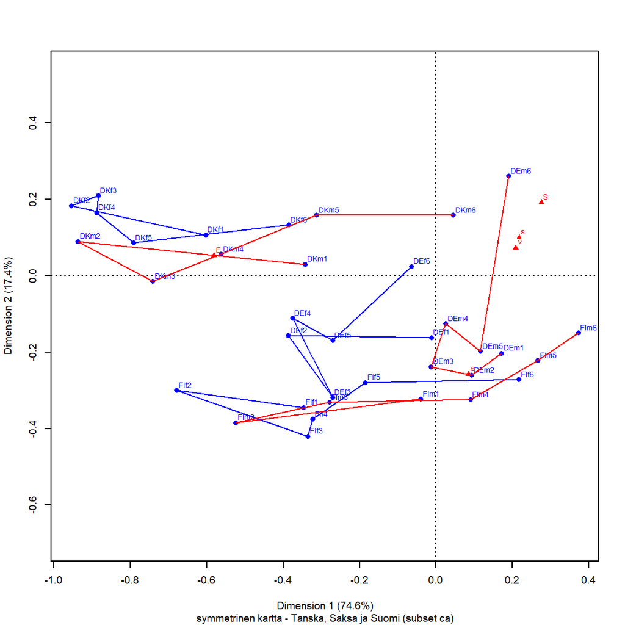

Ikä, sukupuoli ja maa:Tanska-Saksa-Suomi

```r
par(cex = 0.6)
plot(maagaCA2sub2,
     sub = "symmetrinen kartta - Tanska, Saksa ja Suomi (subset ca)")
lines(maagaLinesDKDEFI[1:6,1],maagaLinesDKDEFI[1:6,2], col="blue") #DEf
lines(maagaLinesDKDEFI[7:12,1],maagaLinesDKDEFI[7:12,2], col="red")  #DEm
lines(maagaLinesDKDEFI[13:18,1],maagaLinesDKDEFI[13:18,2], col="blue") #DKf
lines(maagaLinesDKDEFI[19:24,1],maagaLinesDKDEFI[19:24,2], col="red")  #DKm
lines(maagaLinesDKDEFI[25:30,1],maagaLinesDKDEFI[25:30,2], col="blue") #FIf
lines(maagaLinesDKDEFI[31:36,1],maagaLinesDKDEFI[31:36,2], col="red")  #FIm
```

Täydentävät maapisteet hieman epäilyttäviä, tarkistettava ovatko oikein.

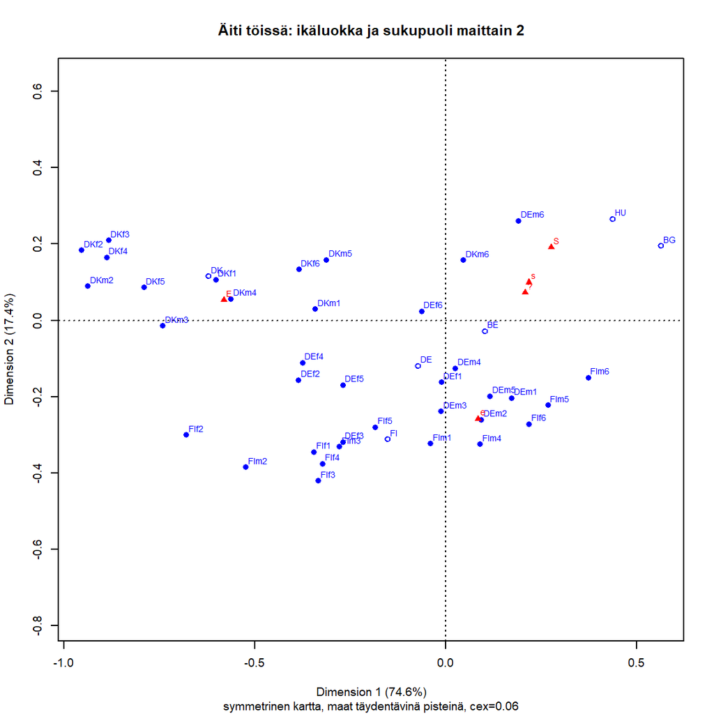

```r
# Osajoukko-ca ja täydentävät maapisteet
# maapisteet suprow = 73:78 toimivat
spCAmaagasub1 <- ca(maagaTab1[,1:5], suprow = 73:78,subsetrow = 25:60 )
par(cex = 0.6)
plot(spCAmaagasub1, main = "Äiti töissä: ikäluokka ja sukupuoli maittain 2",
     sub = "symmetrinen kartta, maat täydentävinä pisteinä, cex=0.06"
    )
```

**Osajoukko-ca neljälle ryhmälle** Belgia on vähän rajatapaus, kokeillaan osajoukko-ca:ta neljällä maaryhmällä. BG-HU, BE-DE-DK-FI,DEDKFI ja BEBGHUsubset

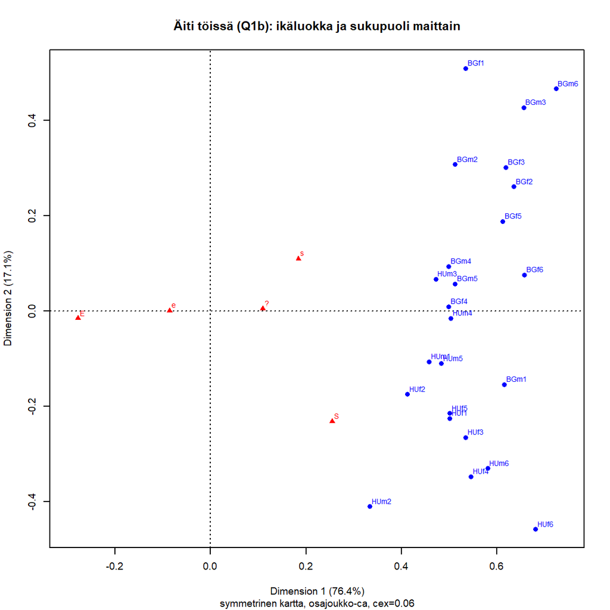

```r
# Neljä maaryhmää
BGHUsubset <- c(13:24,61:72)
BEDEDKFIsubset <- c(1:12, 25:36, 37:48, 49:60)
DEDKFIsubset <- c(25:36, 37:48, 49:60)
BEBGHUsubset <- c(1:12,13:24,61:72)

spCAmaagasub3 <- ca(maagaTab1[,1:5], subsetrow = BGHUsubset)
par(cex = 0.6)
plot(spCAmaagasub3, main = "Äiti töissä (Q1b): ikäluokka ja sukupuoli maittain",
    sub = "symmetrinen kartta, osajoukko-ca, cex=0.06"
    )
```

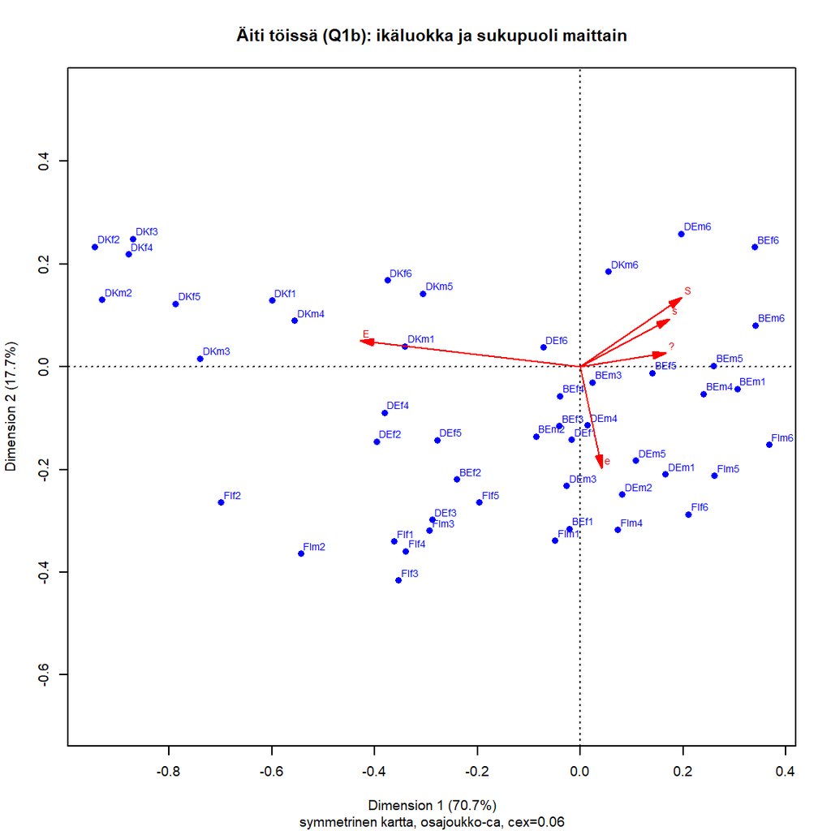

```r
spCAmaagasub4 <- ca(maagaTab1[,1:5], subsetrow = BEDEDKFIsubset)
par(cex = 0.6)
plot(spCAmaagasub4,
     arrows = c(FALSE, TRUE),
     main = "Äiti töissä (Q1b): ikäluokka ja sukupuoli maittain",
     sub = "symmetrinen kartta, osajoukko-ca, cex=0.06"
)
```

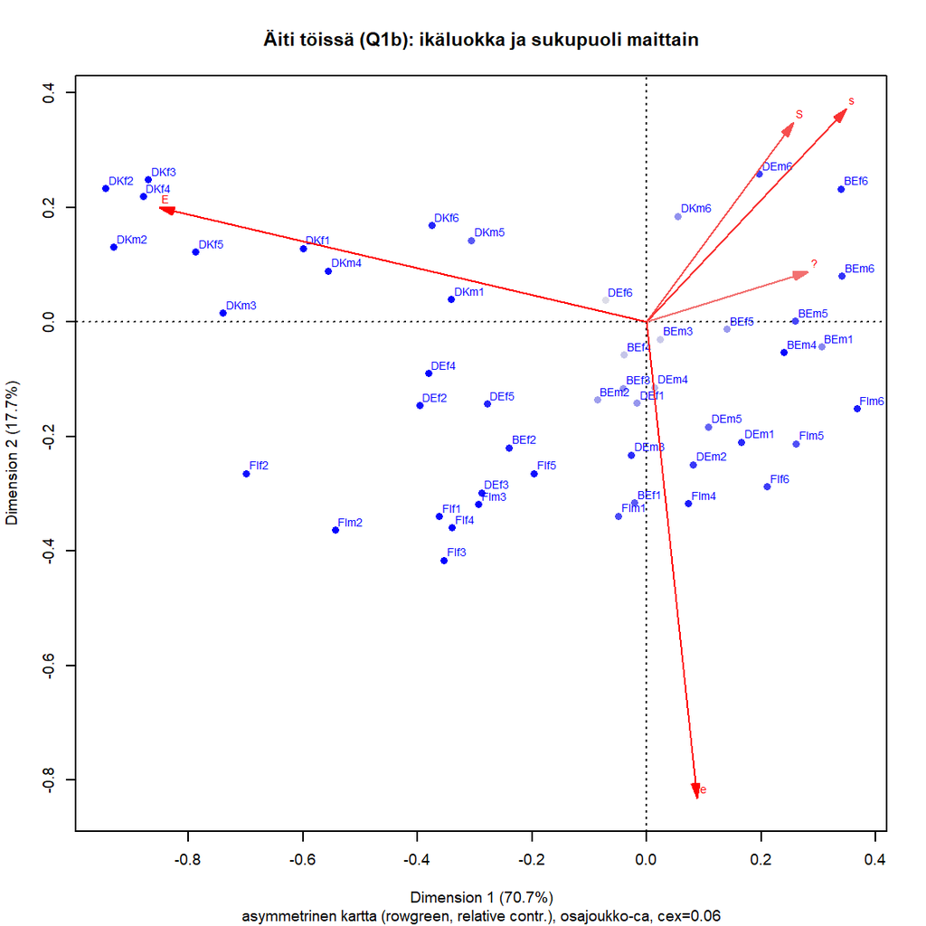

```r
# asymmetrinen kartta
par(cex = 0.6)
plot(spCAmaagasub4,map = "rowgreen",
     contrib = c("relative", "relative"),
     mass = c(FALSE, TRUE),
     arrows = c(FALSE, TRUE),
     main = "Äiti töissä (Q1b): ikäluokka ja sukupuoli maittain",
     sub = "asymmetrinen kartta (rowgreen, relative contr.), osajoukko-ca, cex=0.06"
)
```

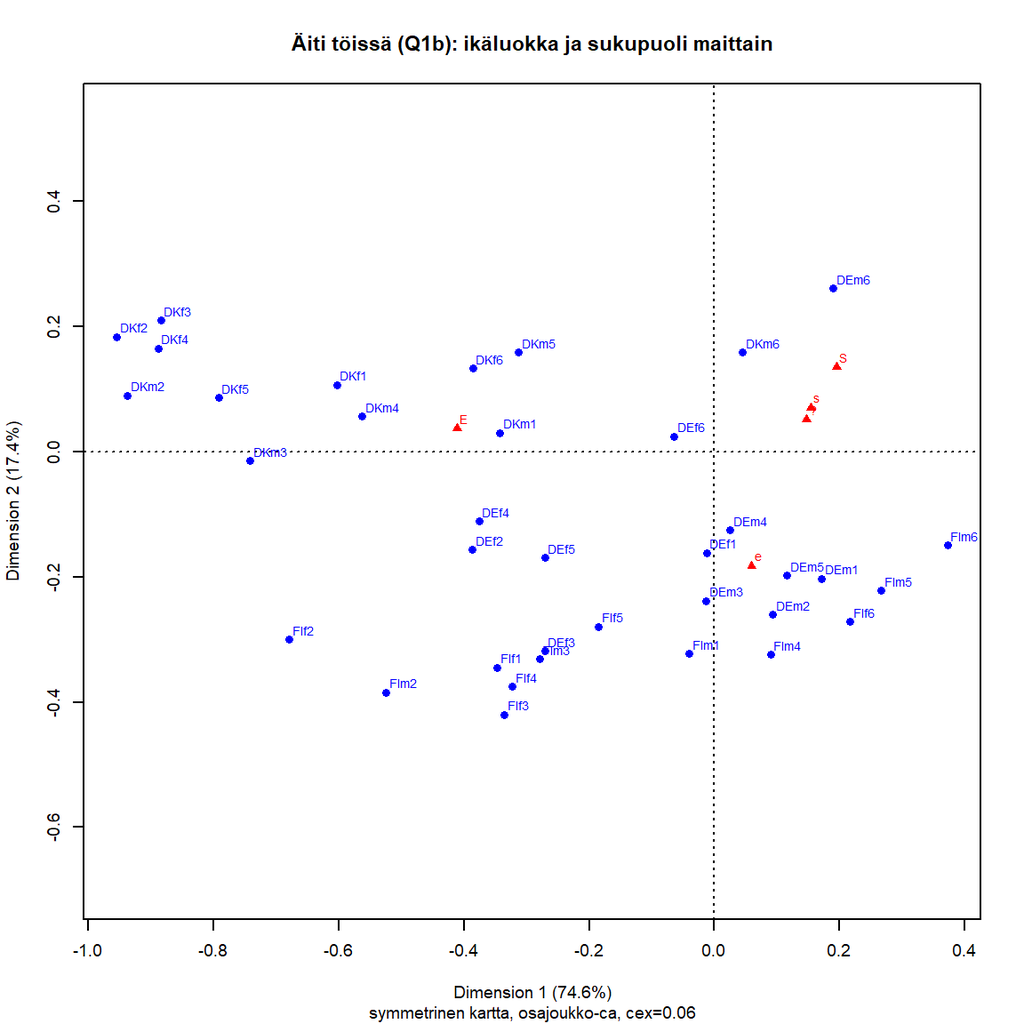

```r
spCAmaagasub5 <- ca(maagaTab1[,1:5], subsetrow = DEDKFIsubset)
par(cex = 0.6)
plot(spCAmaagasub5, main = "Äiti töissä (Q1b): ikäluokka ja sukupuoli maittain",
     sub = "symmetrinen kartta, osajoukko-ca, cex=0.06"
)
```

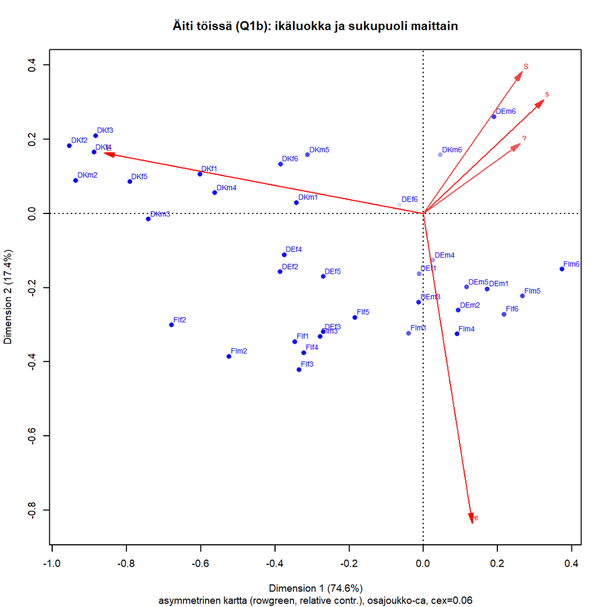

```r
# asymmetrinen kartta
par(cex = 0.6)
plot(spCAmaagasub5,map = "rowgreen",
     contrib = c("relative", "relative"),
     mass = c(FALSE, TRUE),
     arrows = c(FALSE, TRUE),
     main = "Äiti töissä (Q1b): ikäluokka ja sukupuoli maittain",
     sub = "asymmetrinen kartta (rowgreen, relative contr.), osajoukko-ca, cex=0.06"
)
```

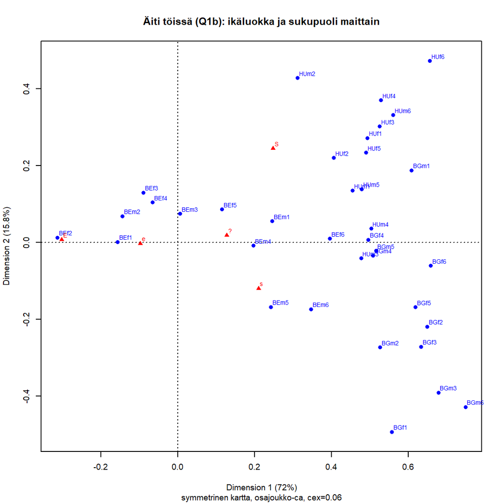

```r
spCAmaagasub6 <- ca(maagaTab1[,1:5], subsetrow = BEBGHUsubset)
par(cex = 0.6)
plot(spCAmaagasub6, main = "Äiti töissä (Q1b): ikäluokka ja sukupuoli maittain",
     sub = "symmetrinen kartta, osajoukko-ca, cex=0.06"
)
```

# 5 Yksinkertaisen korrespondenssianalyysin laajennuksia 2

**TODO** Vielä kuuden maan aineistolla ilman puuttuvia havaintoja? Helpompi havainnollistaa taulukoiden pinoamista / liittämistä (concate, stack). Ja voisi jatkaa ehkä pari pointtia pienellä aineistolla?

```r
# str(ISSP2012jh1d.dat)
# Yksinkertaisuuden vuoksi muuttujat tähän

isodatVars1 <- ISSP2012jh1d.dat %>% names()
isodatVars1 <- isodatVars1[24:73]
demogrVars1 <- c("maa","maa3","sp","ika")
isodatVars1 <- isodatVars1[21:50]
isodatVars1 <- c(demogrVars1, isodatVars1)
isodatVars1
```

```
##  [1] "maa"     "maa3"    "sp"      "ika"     "Q1a"     "Q1b"     "Q1c"
##  [8] "Q1d"     "Q1e"     "Q2a"     "Q2b"     "Q3a"     "Q3b"     "edu"
## [15] "msta"    "sosta"   "nchild"  "lifsta"  "urbru"   "Q1am"    "Q1bm"
## [22] "Q1cm"    "Q1dm"    "Q1em"    "Q2am"    "Q2bm"    "Q3am"    "Q3bm"
## [29] "edum"    "mstam"   "sostam"  "nchildm" "lifstam" "urbrum"
```

```r
ISSP2012jh1d.dat %>% select(all_of(isodatVars1)) %>%
    summary()
```

|  | maa | maa3 | sp | ika | Q1a | Q1b | Q1c | Q1d | Q1e | Q2a | Q2b | Q3a | Q3b | edu | msta | sosta | nchild | lifsta | urbru | Q1am | Q1bm | Q1cm | Q1dm | Q1em | Q2am | Q2bm | Q3am | Q3bm | edum | … |
| --- | --- | --- | --- | --- | --- | --- | --- | --- | --- | --- | --- | --- | --- | --- | --- | --- | --- | --- | --- | --- | --- | --- | --- | --- | --- | --- | --- | --- | --- | --- |
|  | FR : 2409 | FR-France : 2409 | m:14789 | Min. : 15.00 | S :11116 | S :2747 | S :2838 | S :2818 | S :3357 | S :11305 | S :2704 | W : 5373 | W :13722 | Lower secondary (secondary completed does not allow entry to university: obligatory school) :7811 | In paid work :17967 | 06 :6889 | No children:24102 | Married :17573 | A big city :8442 | S:11116 | S:2747 | S:2838 | S:2818 | S:3357 | S:11305 | S:2704 | W: 5373 | W:13722 | Lower secondary (secondary completed does not allow entry to university: obligatory school) :7811 | … |
|  | BE : 2192 | CZ-Czech Republic: 1804 | f:18034 | 1st Qu.: 36.00 | s :12352 | s :8389 | s :8263 | s :7672 | s :8342 | s :13464 | s :5164 | w :15655 | w :13817 | Upper secondary (programs that allows entry to university :7115 | Retired : 7999 | 05 :6798 | One child : 4378 | Civil partnership : 1035 | The suburbs or outskirts of a big city:4386 | s:12352 | s:8389 | s:8263 | s:7672 | s:8342 | s:13464 | s:5164 | w:15655 | w:13817 | Upper secondary (programs that allows entry to university :7115 | … |
|  | CZ : 1804 | AU-Australia : 1557 | NA | Median : 50.00 | ? : 3382 | ? :5949 | ? :6000 | ? :7403 | ? :7841 | ? : 5039 | ? :6109 | H : 8367 | H : 1762 | Post secondary, non-tertiary (other upper secondary programs toward labour market or technical formation):5658 | Unemployed and looking for a job, HR: incl never had a job: 1769 | 07 :5778 | 2 children : 2643 | Separated from spouse/ civil partner (still legally married/ still legally in a civil partnership): 486 | A town or a small city :9203 | ?: 3382 | ?:5949 | ?:6000 | ?:7403 | ?:7841 | ?: 5039 | ?:6109 | H: 8367 | H: 1762 | Post secondary, non-tertiary (other upper secondary programs toward labour market or technical formation):5658 | … |
|  | DE : 1761 | RU-Russia : 1525 | NA | Mean : 49.52 | e : 4074 | e :9003 | e :8706 | e :7863 | e :7267 | e : 1929 | e :9210 | NA’s: 3428 | NA’s: 3522 | Lower level tertiary, first stage (also technical schools at a tertiary level) :5147 | In education : 1763 | 08 :3477 | 3 : 598 | Divorced from spouse/ legally separated from civil partner : 2997 | A country village :8646 | e: 4074 | e:9003 | e:8706 | e:7863 | e:7267 | e: 1929 | e:9210 | P: 3428 | P: 3522 | Lower level tertiary, first stage (also technical schools at a tertiary level) :5147 | … |
|  | AU : 1557 | NO-Norway : 1444 | NA | 3rd Qu.: 63.00 | E : 1051 | E :5547 | E :5960 | E :5016 | E :3462 | E : 403 | E :8917 | NA | NA | Upper level tertiary (Master, Dr.) :4762 | Domestic work : 1180 | 04 :3346 | 4 : 117 | Widowed/ civil partner died : 2763 | A farm or home in the country :1902 | E: 1051 | E:5547 | E:5960 | E:5016 | E:3462 | E: 403 | E:8917 | NA | NA | Upper level tertiary (Master, Dr.) :4762 | … |
|  | RU : 1525 | DK-Denmark : 1403 | NA | Max. :102.00 | NA’s: 848 | NA’s:1188 | NA’s:1056 | NA’s:2051 | NA’s:2554 | NA’s: 683 | NA’s: 719 | NA | NA | (Other) :2022 | (Other) : 1775 | (Other):4758 | (Other) : 45 | Never married/ never in a civil partnership, single : 7535 | NA’s : 244 | P: 848 | P:1188 | P:1056 | P:2051 | P:2554 | P: 683 | P: 719 | NA | NA | Primary school (elementary school) :1531 | … |
|  | (Other):21575 | (Other) :22681 | NA | NA | NA | NA | NA | NA | NA | NA | NA | NA | NA | NA’s : 308 | NA’s : 370 | NA’s :1777 | NA’s : 940 | NA’s : 434 | NA | NA | NA | NA | NA | NA | NA | NA | NA | NA | (Other) : 799 | … |

Data on valmiina, edellisen luvun ikäluokka, ikä-sukupuoli- muuttuja ja ikä-sukupuoli- maa muuttujien luontia voi harkita.

**edit** Tässä keskityttävä data-analyysin **tutkimusongelmiin**, johdantoa MCA-lukuun.

## 5.1 Matriisien yhdistäminen (stacked and concatenated matices)

Ref:CAip, CA_Week2.pdf (kalvot MCA-kurssilta 2017)

Concatenated tables (yhdistetyt taulut tai matriisit): (a) kaksi luokittelumuuttujaa (b) useita muuttujia stacked (“pinotaan”).

MCA 2017 laskareissa ja kalvoissa esitetään, miten nämä saadaan kätevästi CA-paketin MJCA-funktion BURT-optiolla.

## 5.2 Matched matrices

Ref:CAip ss. 177, HY2017_MCA, Greenacre JAS 2013 (sovellus ISSP 1989, 4 kysymystä ‘pitäisikö äidin olla kotona’, 8 maata), tässä artikkelissa “SVD-based methods”, joista yksi CA (muut biplots, PCA, compositional data/log ratios).

Edellisen menetelmän variantti, jossa ryhmien väliset ja sisäiset erot saadaan esiin. Inertian jakaminen. Samanlaisten rivien ja sarakkeiden kaksi samankokoista taulua, esimerkiksi sukupuolivaikutusten arviointi. Alkuperäinen taulukko jaetaan kahdeksi tauluksi sukupuolen mukaan. Matriisien yhdistäminen (concatenation) riveittäin tai sarakkeittain ei näytä optimaalisesti mm - matriisien eroja.

Ryhmien välisen ja ryhmien sisäinen inertian erottaminen, **ABBA** on yksi ratkaisu (ABBA matrix, teknisesti block circulanMat matrix).

Luokittelu voi olla myös kahden indikaattorimuuttujan avulla jako neljään taulukkoon (esim. miehet vs. naiset länsieuroopassa verratuna samaan asetelmaan itä-Euroopassa). Samaa ideaa laajennetaan.

Esimerkkinä “Attitudes to women working in 2012”.